# Rapport de veille: L’impact de l’IA dans la mode et le luxe

Samuel Chaineau

3/12/2021

# Introduction

La mode et le luxe sont des secteurs régis par des dimensions visuelle et émotive très fortes. C’est en réalité un « success driver » en matière de marketing, stratégie et image de marque. Les défilés, campagnes de pub et images en magazines sont autant de moyens permettant à la couture, haute couture et mode de diffuser les couleurs, coupes et motifs de leurs nouvelles collections. Ainsi, ce secteur nécessite une grande sensibilité mais aussi une expertise très subjective : qu’est-ce qui est beau ou pas ?

Les secteurs artistiques ont longtemps été peu considérés par l’IA comme potentiels champs d’application. Les données y sont peu nombreuses, pas structurées et les personnes y travaillant ont peu voire pas d’intérêt pour les mathématiques, la statistique et l’informatique.

Pourtant, il parait tout à fait vraisemblable que l’Intelligence Artificielle puisse accompagner et aider les entreprises de la mode et du luxe dans leur développement : aussi bien marketing que créatif.

L’objectif de ce rapport est donc d’évaluer les inputs utilisées ou utilisables, le périmètre de connaissances nécessaires et leurs applications réelles.

[figure not shown]

*Détection sur un croquis*

## Les années 2010

La genèse du sujet commence en 1957 avec la théorisation du perceptron. C’est cette invention qui lancera plus tard les réseaux de neurones. Il a fallu cependant attendre les années 2010 pour voir l’essor du Deep Learning et la consécration de cette branche du Machine Learning dans l’analyse d’images.

En effet, la capacité de calcul associé à cette tâche est importante tout comme le volume de données à utiliser. C’est aux alentours des années 2010 que la capacité de calcul (notamment en utilisant la carte graphique ou GPU) explose et permet d’observer l’apparition de l’IA.

Apparaissent alors les réseaux de neurones pour l’analyse d’images donnant naissance à la Computer Vision, permettant de capitaliser sur des bibliothèques d’images. L’industrie de la mode étant faite de shootings, défilés, books et autres catalogues, la synergie parait importante.

## Les données

Qui dit Deep learning dit données et préférablement en volumes importants. Internet permet de trouver différentes sources de qualité divergentes avec des objectifs divers.

Le premier dataset qui est le plus connu est le Fashion MNIST Dataset. Ce dataset est composée de 60 000 images pour l’entrainement et 10 000 pour le test. Les images sont en format 28 par 28, centrées et encoder en une seule dimension (greyscale). Le dataset est libre d’accès et a été conçu à partir de photos faites par Zalando, une plateforme d’e-commerce vestimentaire, sur ses produits.

L’avantage de ce dataset est sa capacité à introduire le potentiel des algorithmes pour la classification de vêtements. Les vêtements sont des objets disposant d’une forme bien précise et avec des caractéristiques propres à des catégories de produits (haut vs pantalons par exemple). Il permet d’imaginer des applications et des cas d’usages en entreprise où les images sont centrées, standardisées et prises de face.

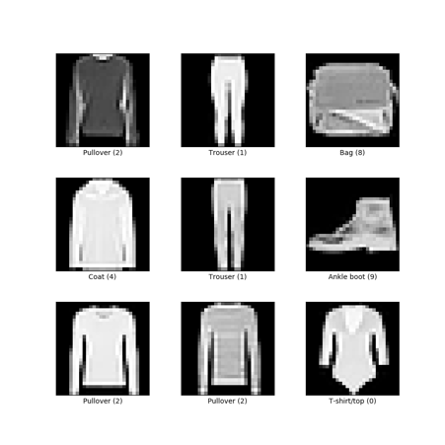

*Fashion MNIST Dataset, 2017*

La limite de ce dataset réside dans son potentiel d’application dans la réalité où les vêtements sont portés, pas centrés, pris de travers et sont au milieu d’une scène. Il apparait alors la notion de détection qui est en fait un point de départ de toute tâche de Computer Vision. La première question à se poser est : où se situe la cible dans l’image ?

Un réseau neuronal très connus qui a répondu à certaines de ces questions est ImageNet. ImageNet est à la fois le nom du modèle mais aussi de la base de données. ImageNet est un modèle entrainé sur plusieurs millions d’images provenant du net et annoté à la main. Certaines de ces images (environ un million) ont également une bounding box permettant de situer l’objet dans la scène.

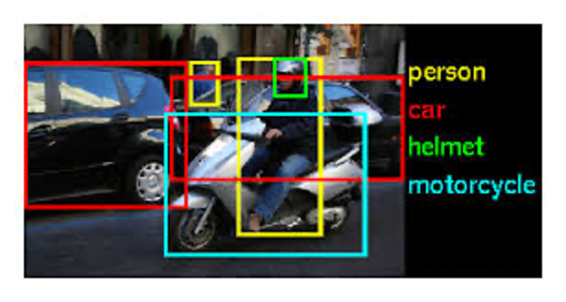

*Un exemple d’image dans la base de données ImageNet*

ImageNet dispose de 1000 classes avec notamment plusieurs dizaines portant sur les vêtements. L’algorithme est capable de détecter la présence ou non d’un vêtement et estimer sa position.

Simplement estimer la position d’un vêtement est une tâche insuffisante. Dans la mode, ce qui compte c’est aussi comment il est porté et donc où se situent certains point clés dans l’image. Une base de données qui permet d’évaluer cela est la base de données « Deep Fashion ». Celle-ci est uniquement dédiée aux vêtements.

Cette base de données de l’université de Hong-Kong permet aussi bien de classé le vêtement, de détecter les matières utilisées mais aussi de retrouver les points de pose permettant d’imaginer la silhouette (épaules, hanches, poignets, poitrine..). Les images sont sur fond blanc cependant, ne correspondant pas à une situation dans la rue ou en défilés.

[figure not shown]

*DeepFashion, 2016 (Première version)*

La base de données ModaNet est quant à elle orientée sur la « street fashion » les images sont uniquement prises dans la rue et extraites via réseaux sociaux. L’objectif n’est plus la détection de vêtements mais la reconnaissance de la zone du vêtement afin d’atteindre un niveau très granulaire. Cette approche 3D du vêtement prouve que la difficulté technique est réelle mais permet d’obtenir des résultats presque aussi complexes que l’analyse humaine.

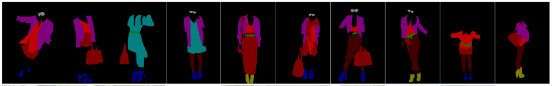

*ModaNet, 2018 (Première version)*

## Les modèles

Les images sont des données particulières à modéliser. Il existe des cas de figures où l’on peut utiliser des Random Forests si les images sont standardisées et statiques (comme le Fashion MNIST par exemple). La problématique apparait lorsque les images bougent, changent…

L’architecture révolutionnaire en matière d’analyse d’image est le réseau de neurones convolutif aussi appelé CNN. Cette architecture permet au modèle d’apprendre par lui-même et dynamiquement selon les pixels fournis. Le CNN se divise en deux grandes phases : une de feature extraction puis une de classification permettant d’assigner le label à l’image. Il s’affranchit de la notion de « statisme » évoquée car il raisonne par régions qui sont combinés petit à petit.

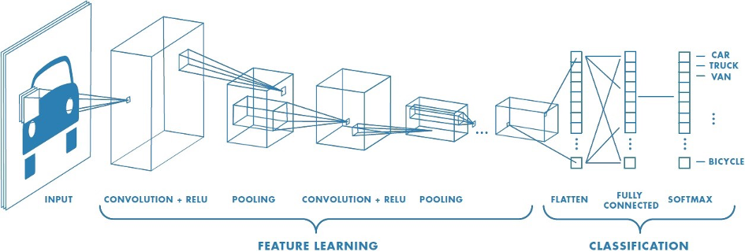

*Architecture d’un CNN*

Ce concept de « base » a permis l’apparition d’autres types de réseaux comme les Region based Convolutionnal Neural Netwrok (RCNN) et aussi les Mask-RCNN qui cherche à détecter des silhouettes et non plus des carrés.

Les problématiques de ces modèles sont la quantité de données nécessaires pour l’apprentissage et aussi leurs mauvaises performances sur des classes peu vues ou inconnues. De plus en plus d’études portent sur le Fewshot learning afin de remédier à ce souci de taille de jeu de données.

## La littérature

À l’aide d’un scrapper sous python, j’ai pu analyser les articles de recherches publiés sur des thèmes données et extraire leurs dates et titres. Le jeu de données est disponible sur le Github.

J’ai effectué 5 recherches sur les thèmes suivant : Computer Vision CNN, CNN image detection, clothes recognition, person detection et fashion deep learning. Permettant d’extraire 250 publications (50 par recherches) mais 246 publications uniques (4 doublons). Les publications retenues sont les premières renvoyées par Google Scholar donc les plus populaires/citées.

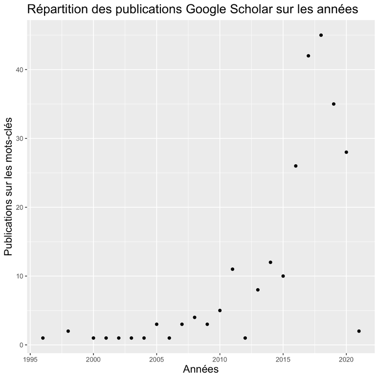

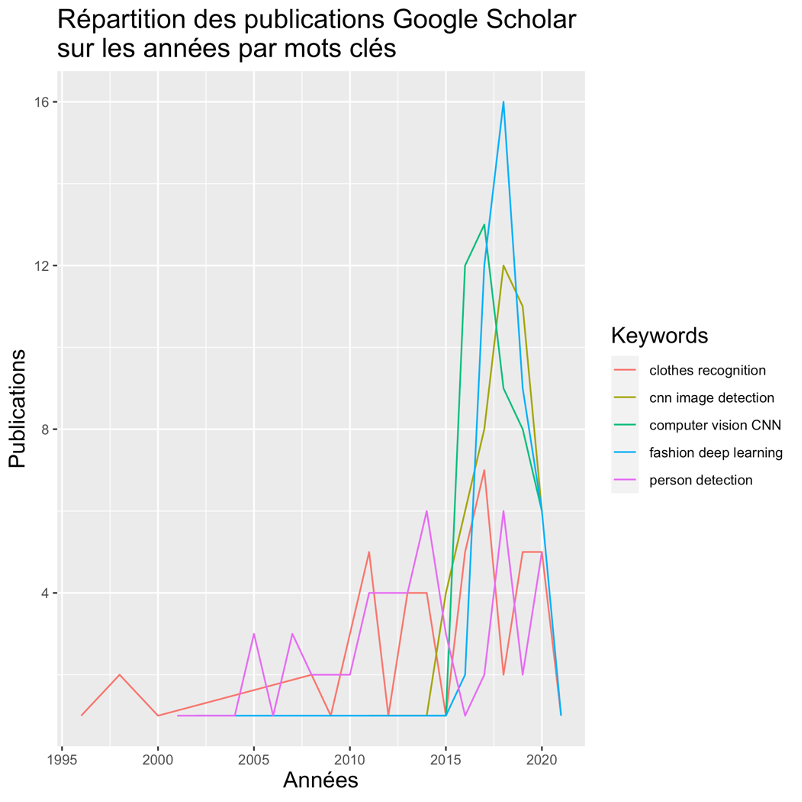

En faisant un nuage de mots sur les titres des publications, et en filtrant les mots superflus, on obtient la visualisation suivante :

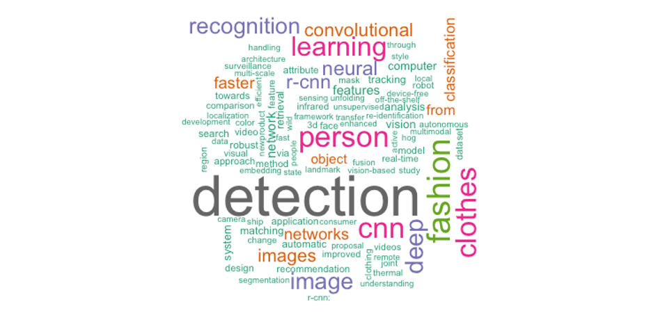

On voit des sous-thèmes apparaitre comme R-CNN, infrared, 3d face… Cet écosystème de thématiques nous montre comment cela s’organise. Les pistes connexes à la COmputer Vision sont nombreuses et laissent présager des progrès importants avec l’aide de nouvelles technologies.

## Les entreprises

Une entreprise dans la mode gère trois populations: les vendeurs (business), les clients et les créateurs. Ces trois populations sont interdépendantes car un créateur attend des retours positifs de ses clients et également une capacité à vendre de la part des vendeurs. Inversement, les clients attendent du créateur sa touche particulière et des vendeurs une expérience personnalisée. On va voir que l’IA a un impact sur les trois populations.

Pour bien saisir, il faut s’intéresser à l’identité d’une marque. Elle se traduit d’abord par ses visuels (petit bonhomme en haut) mais aussi par un ensemble de descriptions verbales (critiques, émotions, mots..). Chacun de ces composants de l’identité d’une marque peuvent être analysés par l’IA. D’abord par Computer Vision pour les visuels ou par NLP pour le “ressenti”.

Cette donnée vient alors s’imbriquer avec les données “business” existantes pour créer un nouveau paradigme plus élaboré.

Les potentiels d’applications sont l’aide à l’inspiration (Eva Generate par exemple), les prévisions de ressenti ou alors une meilleure business intelligence liée à la réalité de la collection.

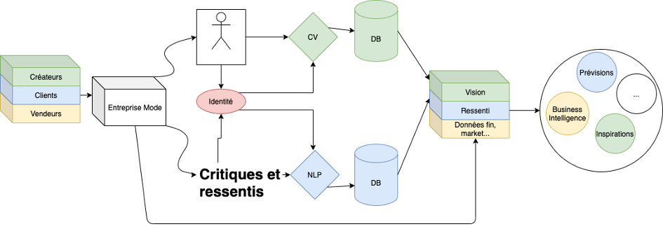

*Schéma de la valeur ajoutée pour l’entreprise*

Eva Engines est une entreprise française créée par Céline Delaugère, diplômée en maths et recherche mais aussi mannequin.Elle commercialise un produit permettant d’obtenir une vue réaliste d’un vêtement à aprtir d’un croquis. Il faut choisir des paramètres comme la couleur, la matière et la taille. L’objectif est de faciliter la création mais aussi de réduire la phase de prototypage.

Elle prépare aussi un moteur de recherche pour mannequin avec un accent mis sur la compatibilité entre l’identité du défilé et ce que le mannequin “transmet”.

[figure not shown]

*Logo Eva Engines*

Heuritech est une entreprise française fondée par Tony Pinville, docteur en informatqiue. L’idée lui est venue suite à un hackathon pour LVMH. Le concept est de scrapper les réseaux sociaux afin de prédire les tendances (vêtements, couleurs, motifs) de demain. Ils analysent des millions d’images par jour avec une grande précision dans la détection des compasants du vêtement (60 types de cols différents).

L’entreprise a levée 4 millions d’euros récemment et vise un déploiement à l’internatonal.

[figure not shown]

*Logo Heuritech*

## Conclusion

Les français sont bons en maths (plus grand nombre de médaille Fields/habitant) et bons en mode… Pour la première fois, un secteur “tech” apparait légitiment de souveraineté française car Paris influence le monde. La presse couvre encore assez peu ce phénomène mais les grandes maisons agissent afin d’intégrer les meilleurs pousses dans leurs chaines de valeur.

L’impact de l’IA couvre tous les pans des entreprises, laissant entrevoir la possibilité d’un nouveau paradigme pour le secteur.

Sources:

Diigo : https://www.diigo.com/user/samchain

Entretiens: https://drive.google.com/drive/folders/1UHwwXJz8hMe4-qscQ3eYfXEABTQlT7-5